# Stats 451 Final Project

Junfeng Luo (jfluo), Dong Ding (dingdo)

```r
library(dplyr) # use 'dplyr' to clean data
library(rstan) # use 'stan' for Bayesian Inference
rstan_options(auto_write = TRUE)
options(mc.cores = parallel::detectCores())
```

# Processing Data

```r
data = read.csv("https://raw.githubusercontent.com/jfluo100/Stats451_FinalProject/master/Brooklyn_Bridge_Automated_Pedestrian_Counts_Demonstration_Project.csv") # load data from github

dim(data) # 7296 is the number of observations (7296/24 = 304 days), 12 is the number of variables
```

```
## [1] 7296   12
```

```r
names(data) # the name of variables
```

```
##  [1] "hour_beginning"    "location"          "Pedestrians"
##  [4] "Towards.Manhattan" "Towards.Brooklyn"  "weather_summary"
##  [7] "temperature"       "precipitation"     "lat"
## [10] "long"              "events"            "Location1"
```

```r
unique(data[, "weather_summary"]) # there are 10 unique weather categories
```

```
##  [1] clear-night         partly-cloudy-night clear-day
##  [4] partly-cloudy-day   rain                cloudy
##  [7] wind                fog                 snow
## [10] sleet
## 11 Levels:  clear-day clear-night cloudy fog ... wind
```

```r
data = data %>%
  filter(events == '') %>%
  select(-lat, -long, -events, -Location1) # only keep the variables we are interested in
```

# What does the data look like?

Our data is about the number of pedestrians that walks across the Brooklyn Bridge along with infomation about time, weather, temperature, etc.

```r
head(data)
```

|  | hour_beginning | location | Pedestrians | Towards.Manhattan | Towards.Brooklyn | weather_summary | temperature | precipitation |
| --- | --- | --- | --- | --- | --- | --- | --- | --- |
| 1 | 10/01/2017 12:00:00 AM | Brooklyn Bridge | 44 | 30 | 14 | clear-night | 52 | 1e-04 |
| 2 | 10/01/2017 01:00:00 AM | Brooklyn Bridge | 30 | 17 | 13 | partly-cloudy-night | 53 | 2e-04 |
| 3 | 10/01/2017 02:00:00 AM | Brooklyn Bridge | 25 | 13 | 12 | partly-cloudy-night | 52 | 0e+00 |
| 4 | 10/01/2017 03:00:00 AM | Brooklyn Bridge | 20 | 11 | 9 | partly-cloudy-night | 51 | 0e+00 |
| 5 | 10/01/2017 04:00:00 AM | Brooklyn Bridge | 18 | 10 | 8 | partly-cloudy-night | 51 | 0e+00 |
| 6 | 10/01/2017 05:00:00 AM | Brooklyn Bridge | 16 | 12 | 4 | partly-cloudy-night | 50 | 0e+00 |

It is obvious that the volume of pedestrians fluctuates in a single day.  
We can see that most people cross the bridge between 10am and 8pm.

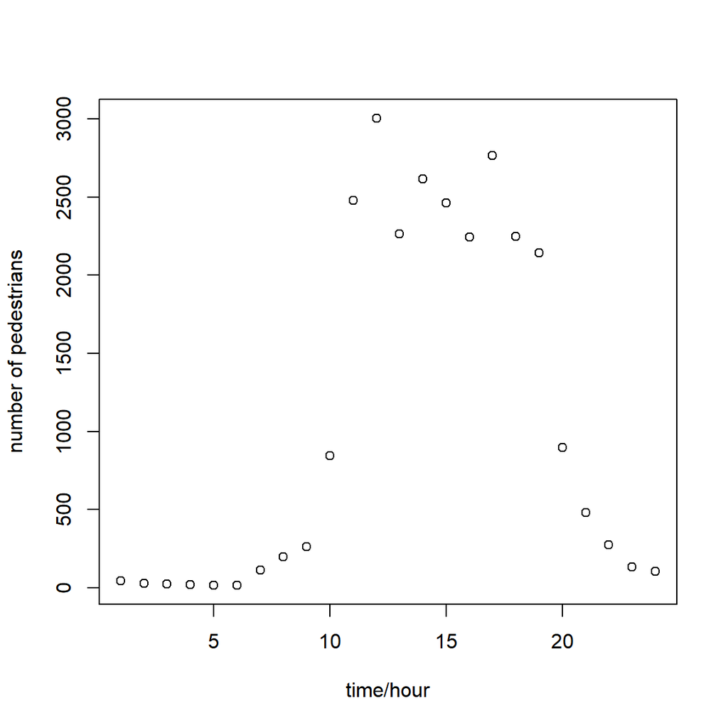

```r
data_first_day = data[1:24, "Pedestrians"]
plot(x = 1:24, y = data_first_day, xlab = 'time/hour', ylab = 'number of pedestrians')
```

It is better we set “per day” as the unit for time.

```r
day_sum = rep(0, times = dim(data)[1])
day_Mhtn = rep(0, times = dim(data)[1])
day_Brkln = rep(0, times = dim(data)[1])

i = 0
while( i < dim(data)[1]/24 ){
  day_sum[(24*i+1):(24*i+24)] = sum(data[, 'Pedestrians'][(24*i+1):(24*i+24)])
  day_Mhtn[(24*i+1):(24*i+24)] = sum(data[, 'Towards.Manhattan'][(24*i+1):(24*i+24)])
  day_Brkln[(24*i+1):(24*i+24)] = sum(data[, 'Towards.Brooklyn'][(24*i+1):(24*i+24)])
  i = i + 1
}

data = mutate(data, day_sum = day_sum, day_Mhtn = day_Mhtn, day_Brkln = day_Brkln) # new dataset
```

## Model Selection

Let us take a look at the distribution of number of pedestrians by day:

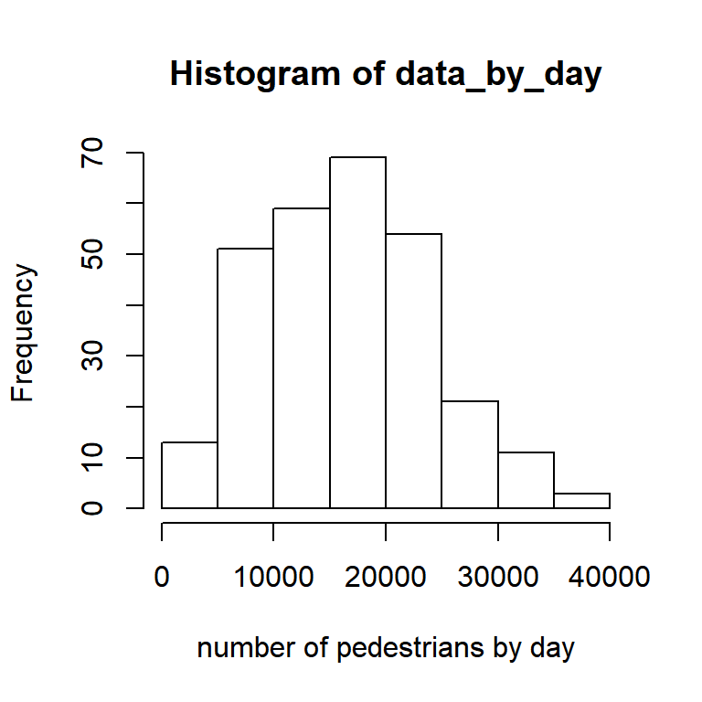

```r
data_by_day = data[seq(1, 6744, by = 24), 'day_sum']
data_Manhattan = data[seq(1, 6744, by = 24), 'day_Mhtn']
data_Brooklyn = data[seq(1, 6744, by = 24), 'day_Brkln']

hist(data_by_day, breaks = 8, xlab = 'number of pedestrians by day')
```

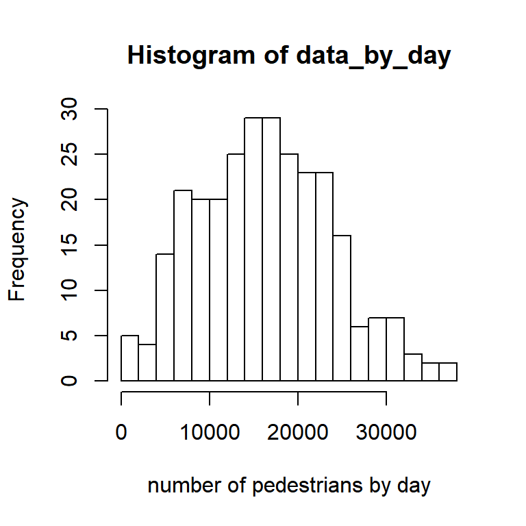

```r
hist(data_by_day, breaks = 20, xlab = 'number of pedestrians by day')
```

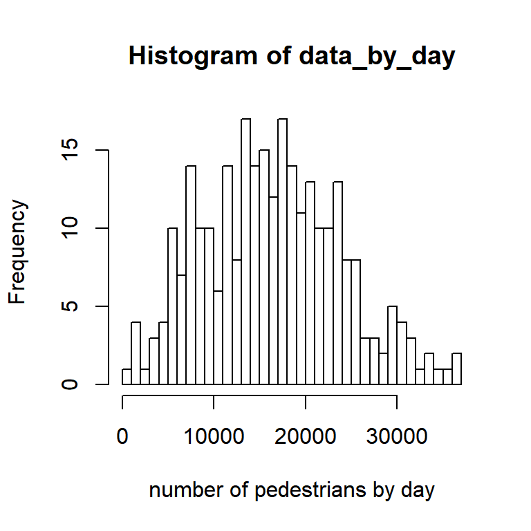

```r
hist(data_by_day, breaks = 40, xlab = 'number of pedestrians by day')
```

Histogram are drawn with different number of bars (same data). It makes sense to use either Gaussian distribution or Poisson distribution here. Both of them are used here.

# Aplly *Stan* Package to Data

## Studying the Influence of weather

```r
## good day and bad day
start = seq(from = 12, to = 19, by = 1) # throughout the year, 11am ~ 6pm are rush hours
index = start
tmp = start
i = 0
while( i < dim(data)[1]/24 ){
  tmp = tmp+24
  index = c(index, tmp)
  i = i+1
}

data_weather = data[index, c('Pedestrians', 'weather_summary')] # only contains data during rush hours

data_good_weather = filter(data_weather, weather_summary %in% c('clear-night', 'clear-day'))[, 'Pedestrians']
data_bad_weather = filter(data_weather, weather_summary %in% c('rain', 'fog', 'snow', 'sleet', 'cloudy', 'wind', 'partly-cloudy-night', 'partly-cloudy-day'))[, 'Pedestrians']
```

### 1) Normal Model

```r
## good day and bad day normal model
model_string <- "
data {
  int<lower = 0> n1;
  int<lower = 0> n2;
  real y1[n1];
  real y2[n2];
}

parameters {
  real mu1;
  real<lower = 0> sigma1;
  real mu2;
  real<lower = 0> sigma2;
}

model {
  for(i in 1:n1 ) {
    y1[i] ~ normal(mu1, sigma1);
  }
  for(i in 1:n2 ) {
    y2[i] ~ normal(mu2, sigma2);
  }
}

generated quantities {
}
"

data_list_weather <- list(y1 = data_good_weather, y2 = data_bad_weather, n1 = length(data_good_weather), n2 = length(data_bad_weather))


# Compiling and producing posterior samples from the model.
stan_samples <- stan(model_code = model_string, data = data_list_weather)

# Plotting and summarizing the posterior distribution
stan_samples
```

```
## Inference for Stan model: fb64e4330fce7b6d002c81972bd02f2d.
## 4 chains, each with iter=2000; warmup=1000; thin=1;
## post-warmup draws per chain=1000, total post-warmup draws=4000.
##
##             mean se_mean    sd      2.5%       25%       50%       75%
## mu1      1741.54    0.35 23.16   1695.14   1726.11   1741.81   1757.07
## sigma1    735.53    0.27 16.32    702.80    724.53    735.77    746.26
## mu2      1367.86    0.33 21.39   1325.81   1353.58   1367.52   1382.12
## sigma2    737.82    0.22 14.90    709.91    727.64    737.42    747.86
## lp__   -15951.28    0.03  1.49 -15954.99 -15951.96 -15950.94 -15950.20
##            97.5% n_eff Rhat
## mu1      1787.56  4334    1
## sigma1    768.21  3578    1
## mu2      1410.62  4181    1
## sigma2    767.46  4564    1
## lp__   -15949.50  2124    1
##
## Samples were drawn using NUTS(diag_e) at Fri Apr 26 20:49:43 2019.
## For each parameter, n_eff is a crude measure of effective sample size,
## and Rhat is the potential scale reduction factor on split chains (at
## convergence, Rhat=1).
```

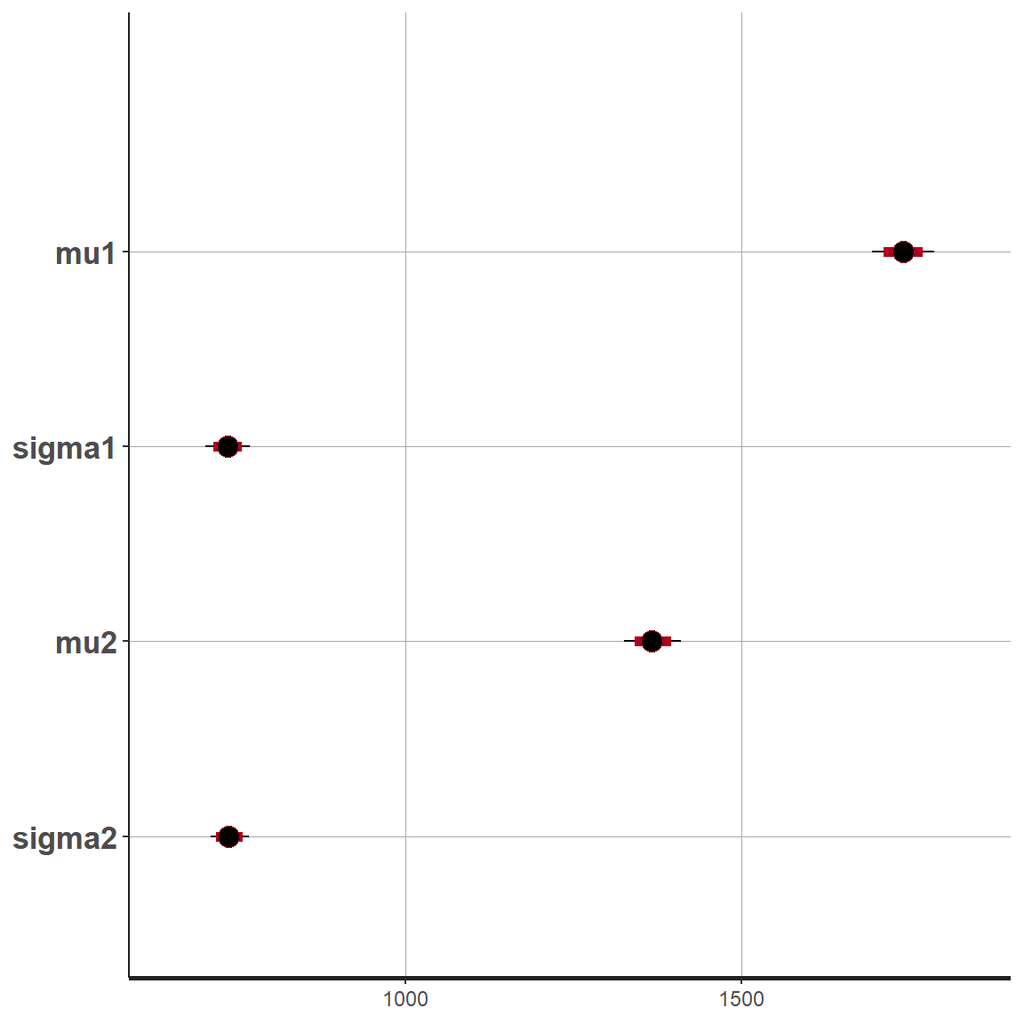

```r
plot(stan_samples)
```

We can see that when the weather is good, the number of pedestrians per hour would follow $N(\mu = 1741, \sigma = 736)$. When the weather is bad, the number of pedestrians per hour would follow $N(\mu = 1368, \sigma = 738)$. We can conclude that there will probably be more pedestrians when the weather is good. Less people will cross the river when it is rainy, cloudy, snowy or sleety.

### 2) Poisson Model

```r
## good day and bad day  possion model
model_string <- "
data {
int<lower = 0> n1;
int<lower = 0> n2;
int y1[n1];
int y2[n2];
}

parameters {
real<lower = 0> lambda1;
real<lower = 0> lambda2;
}

model {
for(i in 1:n1 ) {
y1[i] ~ poisson(lambda1);
}
for(i in 1:n2 ) {
y2[i] ~ poisson(lambda2);
}
}

generated quantities {
}
"
data_list_weather <- list(y1 = data_good_weather, y2 = data_bad_weather, n1 = length(data_good_weather), n2 = length(data_bad_weather))

# Compiling and producing posterior samples from the model.
stan_samples <- stan(model_code = model_string, data = data_list_weather)

# Plotting and summarizing the posterior distribution
stan_samples
```

```
## Inference for Stan model: e1d335a99c99430e9991ca98799cfda6.
## 4 chains, each with iter=2000; warmup=1000; thin=1;
## post-warmup draws per chain=1000, total post-warmup draws=4000.
##
##                mean se_mean   sd        2.5%         25%         50%
## lambda1     1741.23    0.02 1.28     1738.72     1740.37     1741.23
## lambda2     1367.70    0.02 1.06     1365.63     1366.99     1367.70
## lp__    21980667.98    0.02 0.99 21980665.31 21980667.63 21980668.27
##                 75%       97.5% n_eff Rhat
## lambda1     1742.12     1743.76  4087    1
## lambda2     1368.38     1369.86  3400    1
## lp__    21980668.68 21980668.94  1933    1
##
## Samples were drawn using NUTS(diag_e) at Fri Apr 26 20:50:31 2019.
## For each parameter, n_eff is a crude measure of effective sample size,
## and Rhat is the potential scale reduction factor on split chains (at
## convergence, Rhat=1).
```

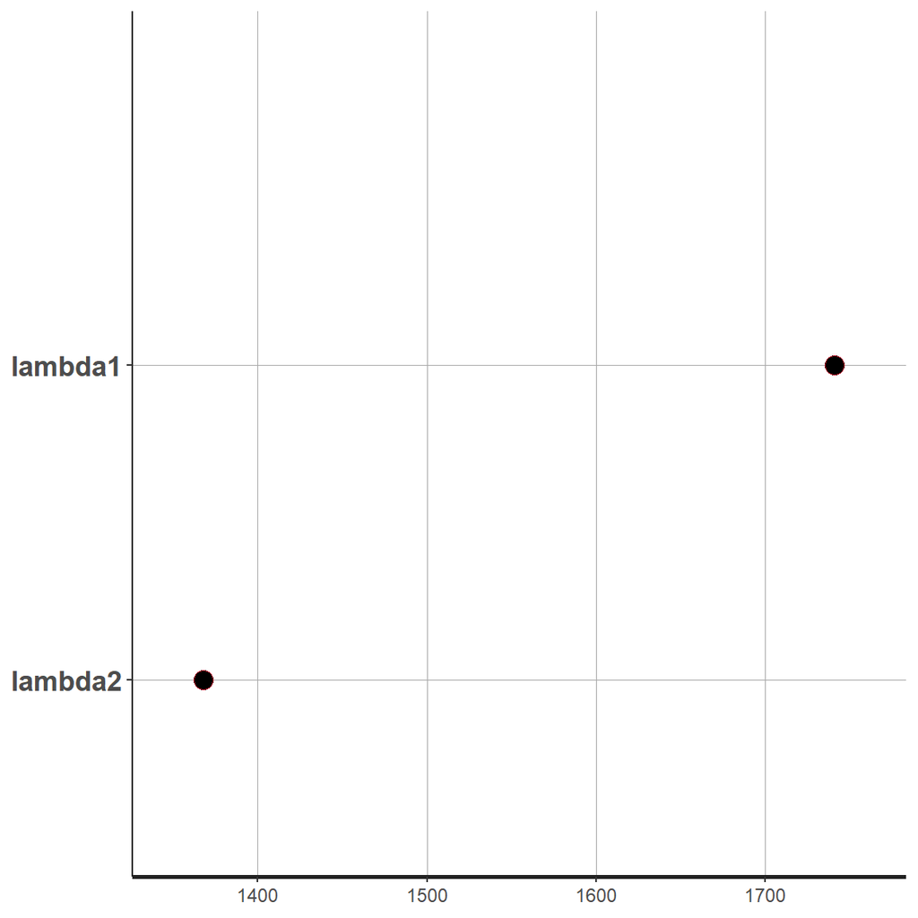

```r
plot(stan_samples)
```

It can be seen that when we use Possion model, the outcome is also easy to interpret. Good weather gives $Pois(\lambda = 1741)$ while bad weather gives $Pois(\lambda = 1368)$. In terms of mean, or expected value, two models come up with the same result.

## Studying the Influence of Temperature

Temperature is another major factor that affects the number of pedestrians.

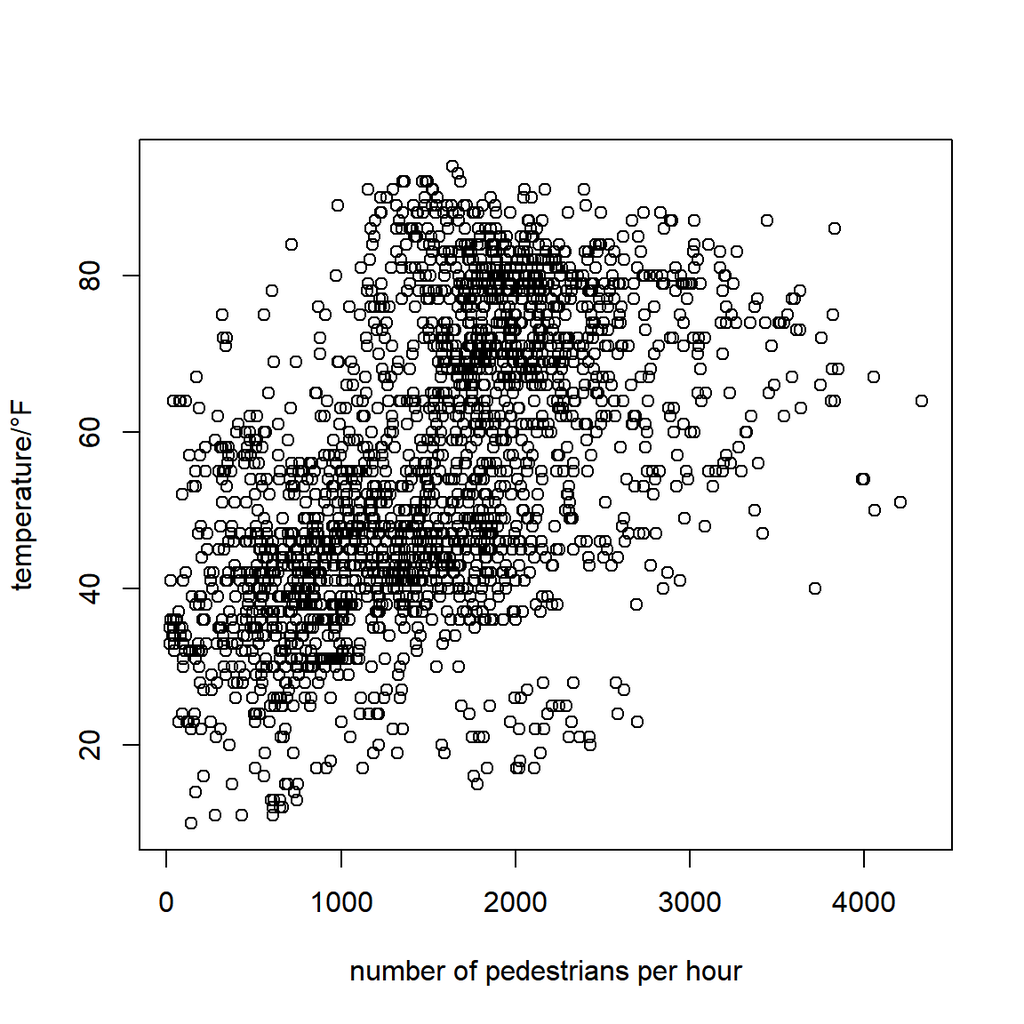

```r
data_temperature = data[index, c('Pedestrians', 'temperature')] # only contains data during rush hours

plot(data_temperature, xlab = 'number of pedestrians per hour', ylab = 'temperature/°F')
```

```r
data_high_temperature = filter(data_temperature, temperature >= 78.8)[, 'Pedestrians'] # above 78.8°F (26°C) would be warm/hot
data_medium_temperature = filter(data_temperature, temperature < 78.8 & temperature >= 50)[, 'Pedestrians'] # 50~78.8°F (8~26°C) would be cool
data_low_temperature = filter(data_temperature, temperature < 50)[, 'Pedestrians'] # below 50°F (8°C) would be cold
```

By talking a quick look at the temperature-volume plot, we can make a guess that higher temperature influences the volume positively.

### 1) Normal Model

```r
model_string <- "
data {
  int<lower = 0> n1;
  int<lower = 0> n2;
  int<lower = 0> n3;
  real y1[n1];
  real y2[n2];
  real y3[n3];
}

parameters {
  real mu1;
  real<lower = 0> sigma1;
  real mu2;
  real<lower = 0> sigma2;
  real mu3;
  real<lower = 0> sigma3;
}

model {
  for(i in 1:n1 ) {
    y1[i] ~ normal(mu1, sigma1);
  }
  for(i in 1:n2 ) {
    y2[i] ~ normal(mu2, sigma2);
  }
  for(i in 1:n3 ) {
    y3[i] ~ normal(mu3, sigma3);
  }
}

generated quantities {
}
"

data_list_temperature <- list(y1 = data_high_temperature, y2 = data_medium_temperature, y3 = data_low_temperature, n1 = length(data_high_temperature), n2 = length(data_medium_temperature), n3 = length(data_low_temperature))


# Compiling and producing posterior samples from the model.
stan_samples <- stan(model_code = model_string, data = data_list_temperature)

# Plotting and summarizing the posterior distribution
stan_samples
```

```
## Inference for Stan model: 21d91a606223d83302e4d40b912f97d9.
## 4 chains, each with iter=2000; warmup=1000; thin=1;
## post-warmup draws per chain=1000, total post-warmup draws=4000.
##
##             mean se_mean    sd      2.5%       25%       50%       75%
## mu1      2000.64    0.39 28.12   1945.23   1982.21   2000.63   2019.62
## sigma1    507.30    0.27 20.25    468.87    493.58    506.29    520.76
## mu2      1812.19    0.35 24.48   1765.09   1795.81   1812.16   1828.20
## sigma2    749.43    0.25 17.55    716.05    737.16    749.11    761.01
## mu3      1127.44    0.29 19.96   1088.80   1113.73   1127.23   1141.22
## sigma3    622.90    0.21 14.51    595.47    612.99    622.58    632.09
## lp__   -15673.50    0.04  1.80 -15677.86 -15674.45 -15673.18 -15672.19
##            97.5% n_eff Rhat
## mu1      2054.78  5294    1
## sigma1    547.27  5487    1
## mu2      1860.78  4925    1
## sigma2    784.73  4809    1
## mu3      1164.89  4793    1
## sigma3    652.74  4795    1
## lp__   -15671.03  1932    1
##
## Samples were drawn using NUTS(diag_e) at Fri Apr 26 20:51:27 2019.
## For each parameter, n_eff is a crude measure of effective sample size,
## and Rhat is the potential scale reduction factor on split chains (at
## convergence, Rhat=1).
```

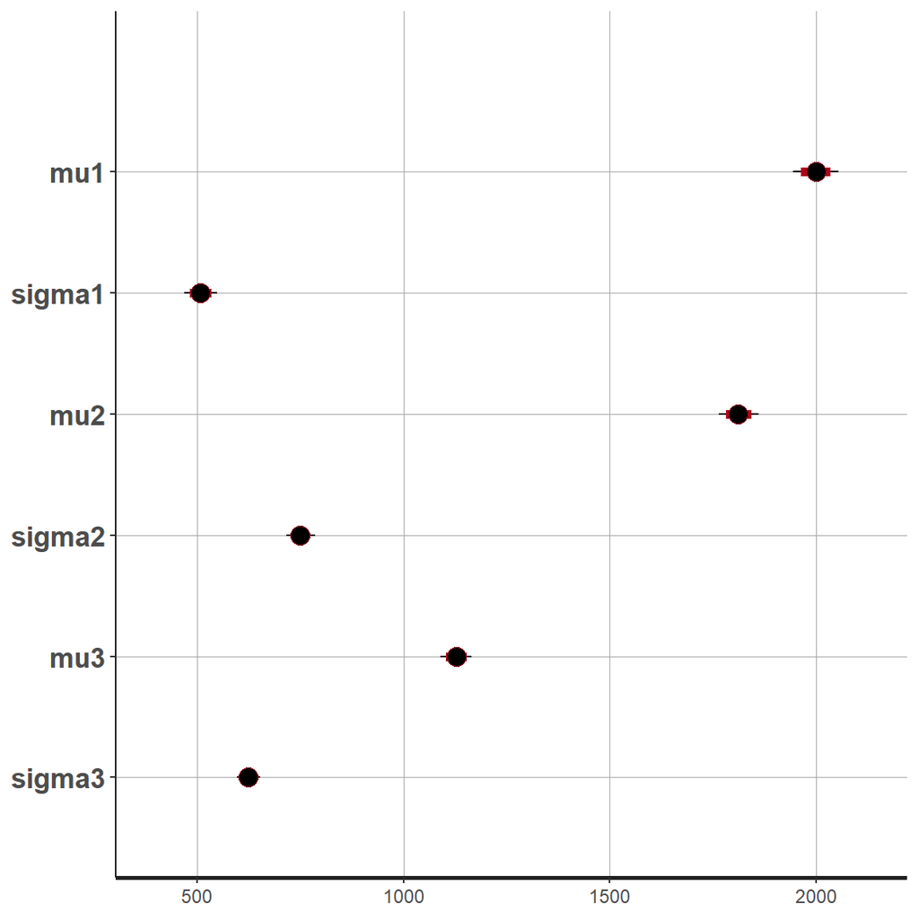

```r
plot(stan_samples)
```

On warm or hot days, there are typically 2001 people who cross the bridge every busy hour. When the temperature is medium, the number is 1811. Only 1127 people walk through the bridge when it is cold.

### 2) Poisson Model

```r
model_string <- "
data {
  int<lower = 0> n1;
  int<lower = 0> n2;
  int<lower = 0> n3;
  int y1[n1];
  int y2[n2];
  int y3[n3];
}

parameters {
real<lower = 0> lambda1;
real<lower = 0> lambda2;
real<lower = 0> lambda3;
}

model {
for(i in 1:n1 ) {
y1[i] ~ poisson(lambda1);
}
for(i in 1:n2 ) {
y2[i] ~ poisson(lambda2);
}
for(i in 1:n3) {
y3[i] ~ poisson(lambda3);
}
}

generated quantities {
}
"
data_list <- list(y1 = data_high_temperature, y2 = data_medium_temperature, y3 = data_low_temperature, n1 = length(data_high_temperature), n2 = length(data_medium_temperature), n3 = length(data_low_temperature))


# Compiling and producing posterior samples from the model.
stan_samples <- stan(model_code = model_string, data = data_list)

# Plotting and summarizing the posterior distribution
stan_samples
```

```
## Inference for Stan model: 3a2064ab4adfd5d222f2d8e074c04c3a.
## 4 chains, each with iter=2000; warmup=1000; thin=1;
## post-warmup draws per chain=1000, total post-warmup draws=4000.
##
##                mean se_mean   sd        2.5%         25%         50%
## lambda1     2000.49    0.05 2.43     1995.75     1998.88     2000.46
## lambda2     1811.70    0.02 1.35     1809.11     1810.75     1811.68
## lambda3     1127.16    0.02 1.05     1125.10     1126.47     1127.15
## lp__    22057277.55    0.03 1.18 22057274.36 22057276.98 22057277.86
##                 75%       97.5% n_eff Rhat
## lambda1     2002.09     2005.50  2207    1
## lambda2     1812.63     1814.33  5555    1
## lambda3     1127.86     1129.29  3433    1
## lp__    22057278.42 22057278.89  2008    1
##
## Samples were drawn using NUTS(diag_e) at Fri Apr 26 20:52:15 2019.
## For each parameter, n_eff is a crude measure of effective sample size,
## and Rhat is the potential scale reduction factor on split chains (at
## convergence, Rhat=1).
```

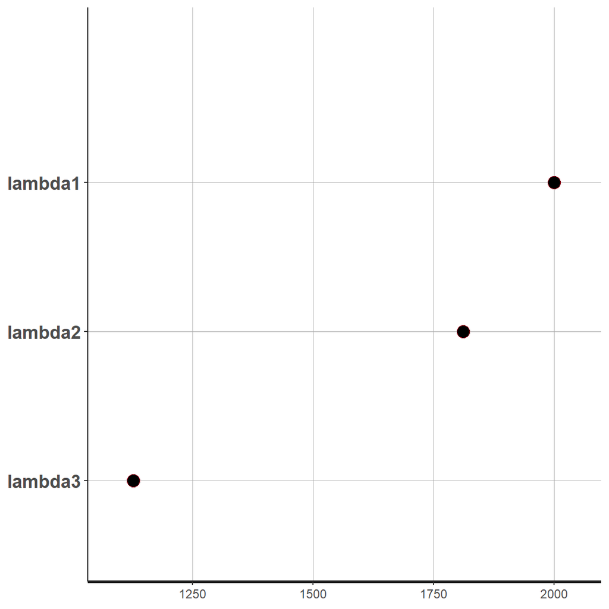

```r
plot(stan_samples)
```

Similar result is concluded from Poisson model:  
High temperature -> $Pois(\lambda = 2001)$ Medium temperature -> $Pois(\lambda = 1811)$ Low temperature -> $Pois(\lambda = 1128)$

# Simulation

## Simulation of Weather

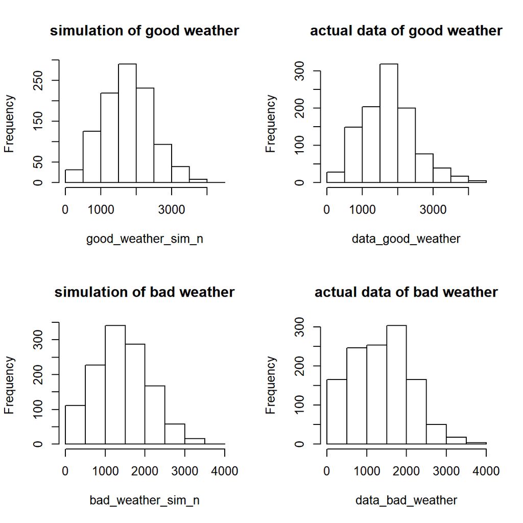

```r
## weather part

# normal ##########
# we should have all data be greater than 0
# so we use truncated normal distribution here
if (!require('truncnorm')) install.packages('truncnorm')
library('truncnorm')
par(mfrow = c(2, 2))

good_weather_sim_n = rtruncnorm(n = 1040, a = 0, b = Inf, mean = 1740.57, sd = 735.57)
hist(good_weather_sim_n, main = "simulation of good weather")
hist(data_good_weather, main = "actual data of good weather")

bad_weather_sim_n = rtruncnorm(n = 1208, a = 0, b = Inf, mean = 1367.25, sd = 737.26)
hist(bad_weather_sim_n, main = "simulation of bad weather")
hist(data_bad_weather, main = "actual data of bad weather")
```

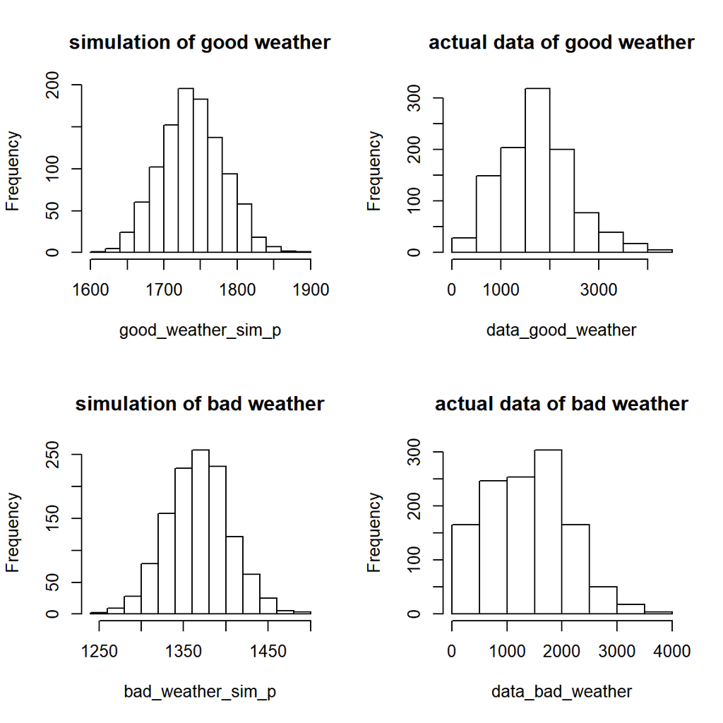

```r
# Poisson ##########
good_weather_sim_p = rpois(n = 1040, lambda = 1740.57)
hist(good_weather_sim_p, main = "simulation of good weather")
hist(data_good_weather, main = "actual data of good weather")

bad_weather_sim_p = rpois(n = 1208, lambda = 1367.25)
hist(bad_weather_sim_p, main = "simulation of bad weather")
hist(data_bad_weather, main = "actual data of bad weather")
```

## Simulation of Temperature

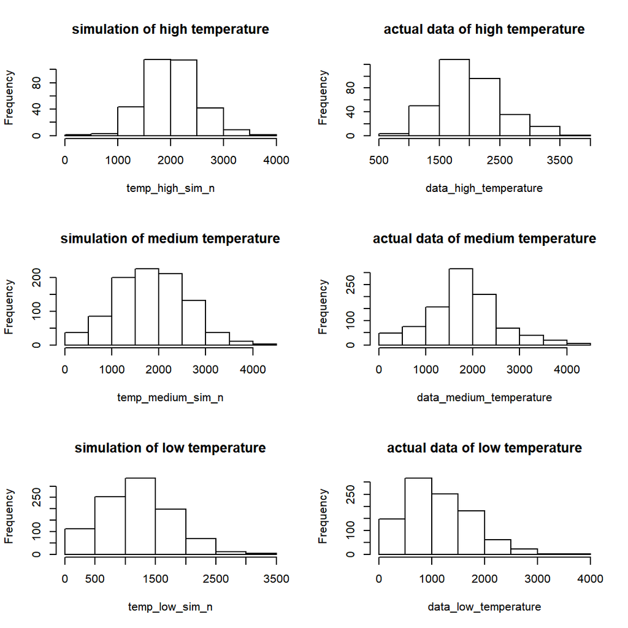

```r
## temperature part

# normal #########
par(mfrow = c(3, 2))
temp_high_sim_n = rtruncnorm(n = 328, a = 0, b = Inf, mean = 2000.49, sd = 507.19)
hist(temp_high_sim_n, main = "simulation of high temperature")
hist(data_high_temperature, main = "actual data of high temperature")

temp_medium_sim_n = rtruncnorm(n = 939, a = 0, b = Inf, mean = 1811.81, sd = 749.19)
hist(temp_medium_sim_n, main = "simulation of medium temperature")
hist(data_medium_temperature, main = "actual data of medium temperature")

temp_low_sim_n = rtruncnorm(n = 981, a = 0, b = Inf, mean = 1127.74, sd = 622.99)
hist(temp_low_sim_n, main = "simulation of low temperature")
hist(data_low_temperature, main = "actual data of low temperature")
```

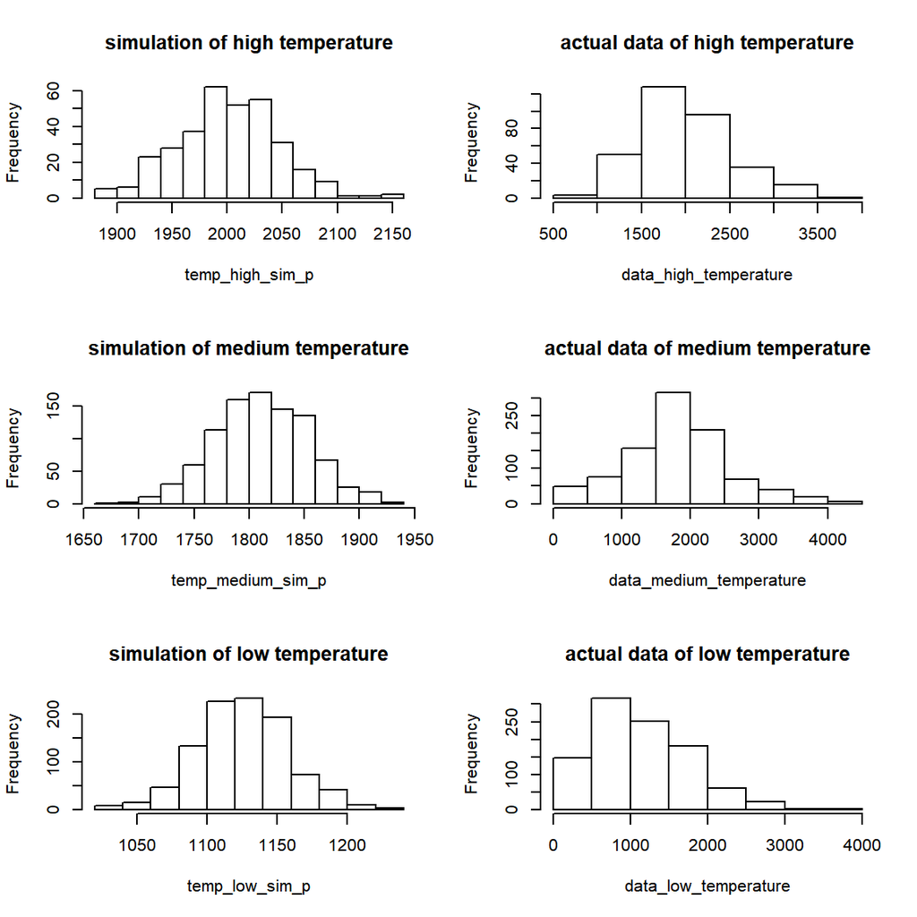

```r
# Poisson #########
temp_high_sim_p = rpois(n = 328, lambda = 2000.61)
hist(temp_high_sim_p, main = "simulation of high temperature")
hist(data_high_temperature, main = "actual data of high temperature")

temp_medium_sim_p = rpois(n = 939, lambda = 1811.68)
hist(temp_medium_sim_p, main = "simulation of medium temperature")
hist(data_medium_temperature, main = "actual data of medium temperature")

temp_low_sim_p = rpois(n = 981, lambda = 1127.16)
hist(temp_low_sim_p, main = "simulation of low temperature")
hist(data_low_temperature, main = "actual data of low temperature")
```

# Conclusion

Compared to bad days, 25% more people cross the bridge when the weather is fine.

40% less people pass the bridge when it is cold outside. Maybe summer is the time tourists hike in New York City.